# Production Information System

CHAPTER 2: DataBase Modeling and Design - The Relational DataBase Model

Dr. Jomana Bashatah

ISE Department - Year 4/ Level 7

2025-08-31

## Outline

1. Introduction
2. The DataBase Management System (DBMS)
3. The Relational DataBase (RDB)
4. Key Attributes and Linking Tables
5. Structured Query Language (SQL)

## 1. Introduction

In this chapter, we introduce the basic concepts of the relational database. Early attempts at developing database systems were based on the **hierarchical** and **network** models. However, these have been largely displaced in industry by the **relational** model, which is the foundation of modern database management systems. Therefore, it shall be the relational model that we focus on exclusively in this chapter.

## 2. The Database Management System (DBMS)

The database system has both hardware and software components.

• Hardware is the physical storage medium for the data (hard disk, tape, etc.)

• The software is the medium through which the user accesses the physically stored data.  
→ the database management system (DBMS)

The DBMS allows the user to store, retrieve, and update data without having particular knowledge about the physical location of data or how related data are stored.

## 2. The Database Management System

• The most widely used DBMSs are relational (RDBMSs)

• There are three classes of database systems with different levels of complexity and sophistication: enterprise databases, workgroup databases, and personal databases.

- Enterprise Database
- Workgroup Database
- Personal Database

• An **enterprise database** is a large database that runs on one or more servers and may have client users spread throughout many locations. It must be capable of handling a large quantity of transactions and the execution must be in real-time.  
- For example, a transaction involving an ATM debit should be recorded in the time frame of seconds. It uses sophisticated security measures and can allow different levels of access by client users.  
- Database management systems such as Oracle (Oracle Corporation) and DB2 (IBM) are typically used for these applications.

• A **workgroup database** typically runs on one server and distributes information to several client machines running on the same local area network.

• The level of transaction processing is much lower than that of an enterprise database, but the DBMS must be capable of handling multiple clients who are independently generating transactions that change the contents of one or more databases running concurrently on the DBMS.  
- Microsoft’s SQL Server, which supports client-server architecture, is a popular choice for workgroup applications.

• A personal database runs on a single personal computer

• It has a lower transaction handling rate and is not designed with sophisticated administrative tools for setting levels of security

• The Access DBMS is a good example of a personal database

## 2. The Database Management System

The relational database uses the concepts of attribute, domain, relation, tuple, and primary key.

- Attribute
- Domain
- Relation
- Tuple
- Primary Key

An **attribute** is a name, or label, for a set of data that refer to the same thing.

**Example:** “employee_last_name” could be a label for a set that contains the last names of the employees of an enterprise.

A **domain** is the smallest unit of data in the database.

**Example:** If the enterprise has three employees (Joseph Smith, John Doe, and Mary Murphy), then the three values “Smith,” “Doe,” and “Murphy” are the domain of the attribute “employee_last_name.”

A **relation** refers to a set of related attributes as defined by a user.

**Example:** The following three attributes: “employee_SS_no,” “employee_last_name,” and “employee_first_name.” If the user defines these three attributes as a relation, then the following data set is defined as a relation:

- 036-27-5192, Smith, Joseph
- 357-19-9921, Doe, John
- 142-36-1529, Murphy, Mary

A **tuple** is a set of related data from within a relation.

**Example:** The previous example has three tuples, each consisting of a value for employee_SS_no, employee_last_name, employee_first_name.

A **primary key** is an attribute in which the domain value is unique (i.e., not repeated in any tuple of the relation).

**Example:** In the previous example, employee_SS_no corresponds to a primary key. The attributes employee_last_name and employee_first_name do not correspond to primary keys because it may be possible at some future time to have two or more employees with the same last or first names.

## 3. The Relational DataBase (RDB)

• A relational model allows the user to view the data in a simple intuitive tabular structure, called a table.

• This structure allows the user to model the logic of the data manipulation such that it is independent of the physical storage of the data.

• A table is a logical view of related data. The table is defined by the entity set and attributes that it represents.

• An entity is a person, place, event, concept, or thing about which information is to be kept in the database tables.  
- For example, a particular employee, a specific material, or a manufacturing process plan for a particular component could qualify as entities.

## 3. The Relational DataBase (RDB)

• A related group of entities, the information about which is maintained in the same table, is called an entity set. Each entity set has unique characteristics, which is the set of information that is kept on that entity set.

• These unique characteristics are called attributes

• An attribute consists of an attribute name, and no two attributes of the database may have the same name

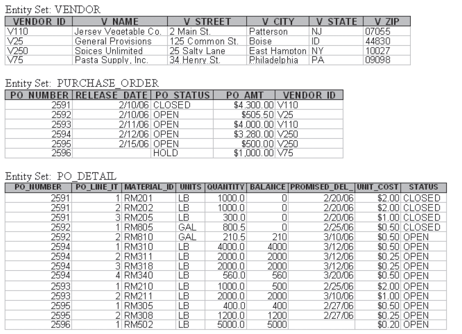

## 3. The Relational Database (RDB)

• A table is a **relation** because it contains a set of attributes about a group of related entities, the entity set

• A database contains many such tables and that these tables are related to one another  
- For example, the table VENDOR is related to the table PURCHASE_ORDER by the attribute that is common to both tables (i.e., the VENDOR_ID). However, the term relational in relational database does not refer to the relationships among tables, but to the fact that the entities in the entity set of a table are related by a common set of attributes

## 3. The Relational Database

• Tables are constructed of rows and columns, and we usually use these terms in referring to a table structure

- Row
- Column

• A row represents a single entity, or instance of the entity set.  
- A row is sometimes referred to as a record, which is a term carried over from a period when computer information was maintained in a file structure

• A column represents the attributes of the entity set. Sometimes columns are referred to as fields  
- Ex: The VENDOR table contains four rows (entities or records) and six columns (attributes or fields)

## 3. The Relational Database

• Relational database management systems support a variety of data types.

• Typical data types are numeric, character or text, date, and currency.

- Numeric
- Character/Text
- Date
- Currency

**Numeric data types** are classified as integer, floating point, or decimal

- Integer Types
- Floating Point
- Decimal

Integer types are either SMALLINT (also referred to as Integer in Microsoft Access) or INTEGER (also referred to as Long Integer in Microsoft Access).

Floating point includes Single precision (4 bytes of data storage) and Double precision (8 bytes of data storage).

The Decimal data type is a formatted data type in which the DBMS stores the number, including fractional parts, as an integer with up to 12 bytes of data storage.

**Character** or **text data** are represented as an alphanumeric string in the range of 1 to 254 characters.

The length of the string is indicated in parentheses following the type designation, as in CHAR(10).

- All of the attributes in the table VENDOR could be character data types. Although V_ZIP (zip code) could be a SMALLINT, it is not a number that would usually be subject to a mathematical calculation.

The **DATE data type** tells the DBMS to interpret the field as a date.

- The attribute RELEASE_DATE in the table PURCHASE_ORDER and PROMISED_DEL_DATE in the table PO_DETAIL are examples of the DATE data type.

The **CURRENCY data type** tells the DBMS that the numerical value is a monetary value.

- The attribute PO_AMT in PURCHASE_ORDER and UNIT_COST in PO_DETAIL are examples of the CURRENCY data type.

• When the attribute fields of a table are defined, the user also defines the data type. When values are entered into the table, the DBMS will not allow the user to enter data into an attribute field that does not conform to the data type of that attribute.

## 4. Key Attributes and Linking Tables

• To maintain the integrity of a database, certain attributes of each table are designated as key attributes. The two most important key attributes are the primary key and the foreign key attributes.

Primary Key

Uniquely identifies each row in a table

**Example:** VENDOR_ID in VENDOR table

**Key Properties:**  
• Value appears only once per table  
• Cannot be null  
• Must be declared when table is created  
• Used to ensure retrieved data set is unique  
**Composite Primary Key:**  
• Sometimes a single attribute cannot distinguish rows  
• Example: In PO_DETAIL table, PO_NUMBER repeats for each line item  
• Each purchase order has only one line item 1, one line item 2, etc.  
• Combination of PO_NUMBER and PO_LINE_ITEM creates unique identification  
• This combination becomes a composite primary key attribute

↔

Foreign Key

Links tables together by referencing primary keys

**Example:** PO_NUMBER in PO_DETAIL references PURCHASE_ORDER

**Key Properties:**  
• Can have duplicate values  
• Must reference a primary key in another table  
• Maintains referential integrity  
**Referential Integrity:**  
Ensures all foreign key values have corresponding primary key values in the referenced table

## 5. Structured Query Language

• The relational database community has defined a standard language for manipulating data in a database called Structured Query Language (SQL)

• The American National Standards Institute (ANSI) has standardized SQL

• SQL describes a basic set of keywords and their meaning. Although the standard is largely followed, not all commercial RDBMSs use all the keywords of the standard, and many RDBMSs have extended the standard by adding keywords

## 5. Structured Query Language

• SQL is a nonprocedural language

• In SQL, the RDBMS decides how to get it done. The “what” is defined by the programmer using the SQL command set

• There are about 30 standard instructions in the basic SQL command set. These instructions allow the user to perform operations for the following purposes:  
- (1) to create a database and its table structure,  
- (2) to manage the data in the database tables,  
- (3) to summarize the data into useful information for decision making.